# Instalações

# 1 SQLite

SQLite é uma biblioteca em linguagem C que implementa um banco de dados SQL imbutido. Usando o SQLite não é necessário ter todo o SGBD. O uso do SQLite é recomendado quando a simplicidade da administração, implementação e manutenção são mais importantes que incontáveis recursos que SGBDs, mais direcionados para aplicações complexas, possivelmente implementam. As situações onde a simplicidade é a melhor escolha são muito mais frequentes do que se pode imaginar.

O SQLite cria e acessa os BDs direto em arquivos, usando a linguagem SQL. Para a instalação do SQLite siga os passos:

# 2 Download

Para realizar o download do SQLit acesse https://www.sqlite.org/download.html e baixe o arquivo sqlite-tools-…zip, como mostrado na Figura abaixo:

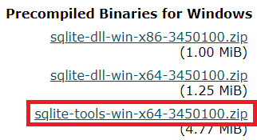

Download SQLite

Ao extrair a pasta, os três arquivos devem estar juntos:

- sqlite3_analyzer
- sqldiff
- sqlite3

# 3 Adicionar o caminho na variável PATH

O arquivo **sqlite3.exe** já é o executável do SQLite. Se clicar duas vezes a seguinte tela de console será inicializada:

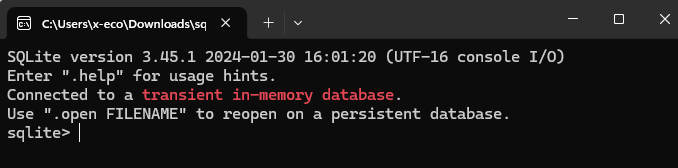

Ou seja, já podemos usar o programa sem nenhuma instalação! No entanto, vamos colocar ele em um local mais conveniente (no momento está na própria pasta de download). Salve pasta com os três arquivos na pasta raiz C:/, se quiser pode alterar o nome da pasta como um todo para sqlite3.

Agora, para conseguirmos acessar o programa de qualquer pasta, precisamos dizer para o sistema operacional o local em que o executável está, adicionando-o na variável PATH. Os passos abaixo indicam o processo no Windows 11:

Acesse **Configurações**

1. Selecione a aba **Sistema**
2. Clique no item **Sobre**
3. Clique no botão **Domínio ou grupo de trabalho**
4. Selecione a aba **Avançado**
5. Clique no botão **Variáveis de Ambiente…**
6. Na janela **Variáveis do Sistema** existe uma “planilha”, clique na linha com o nome **PATH**.
7. Clique em **Novo** e adicione o caminho da pasta salva com o arquivo sqlite3.

Se a pasta se chamar *sqlite3* e estiver na raiz C:\, o caminho fica como na Imagem abaixo:

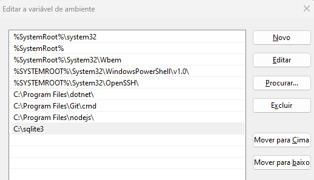

Variável PATH

# 4 Teste

Para testar se a variável foi adicionada corretamente, acesse o terminal (digite cmd na janela de busca), e escreva sqlite3. Se tudo estiver correto, é para aparecer a mesma tela de quando o arquivo sqlite3 foi executado direto da pasta.